# Titanic

21 de febrero de 2017

## Titanic

El RMS Titanic fue un transatlántico británico, el mayor barco de pasajeros del mundo en el momento de su terminación, que se hundió en la noche del 14 al 15 de abril de 1912 durante su viaje inaugural desde Southampton a Nueva York. En el hundimiento del Titanic murieron 1514 personas de las 2223 que iban a bordo, lo que convierte a esta tragedia en uno de los mayores naufragios de la historia ocurridos en tiempo de paz. Construido entre 1909 y 1912 en el astillero Harland and Wolff de Belfast, el Titanic era el segundo de los tres transatlánticos que formaban la clase Olympic, propiedad de la naviera White Star Line, junto al RMS Olympic y, posteriormente, el HMHS Britannic.

Solo se analizarán 891 personas de las que se tienen registro.

## Describir el domino de la información

- Id
- Sobrevivió : 1=Si, 0=no
- Nombre
- Sexo : female= mujer, male=hombre
- Años

## Describir el domino de la información

- Clase de pasajeros : 1=Superior, 2=Mediana or 3=Baja
- Cabina

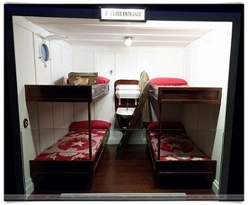

<sub><sup>Exposición Titanic Centenary 2012: La mayoría de los pasajeros de tercera clase, casi todos inmigrantes irlandeses, embarcaron en el Titanic con el objeto de cumplir el sueño de su vida: labrarse un porvenir en America y regresar a Irland</sup></sub>

## Domino de la información. [2]

- Número de hermanos / cónyuges en el extranjero
- Número de padres / niños a bordo
- Tarifa de pasajeros
- Puerto o embarcación: C = Cherbourg, Q = Queenstown, S = Southampton

## Domino de la información. [3]

- Número de Ticket

[figure not shown]

## Describir cada una de las variables.

Cantidad de pasajeros.

```
## [1] 891
```

Cantidad de pasajeros por clase

- En el siglo XIX la prioridad era el transporte
- El Titanic era el mayor y más lujoso barco jamás construido.

(1=Superior, 2=Mediana or 3=Baja)

```
##
##   1   2   3
## 216 184 491
```

## Describir cada una de las variables. [2]

Cantidad de sobrevivientes (0= murió, 1= vivió)

```
##
##   0   1
## 549 342
```

Cantidad de hombre y mujeres

```
##
## female   male
##    314    577
```

Cantidad de sobrevivientes por sexo

```
##
##            0   1
##   female  81 233
##   male   468 109
```

## Describir cada una de las variables. [3]

Número de hermanos / cónyuges en el extranjero

```
##
##   0   1   2   3   4   5   8
## 608 209  28  16  18   5   7
```

Número de Padres / Niños a bordo

```
##
##   0   1   2   3   4   5   6
## 678 118  80   5   4   5   1
```

Cantidad de tickets únicos.

```
## [1] 681
```

## Describir cada una de las variables. [4]

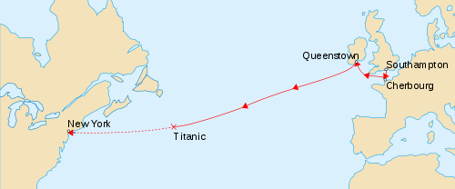

EMBARCACIÓN (C = Cherbourg; Q = Queenstown; S = Southampton)

```
##
##       C   Q   S
##   2 168  77 644
```

## Estadisticas básicas de resumen.

[output not shown]

[output cut: 24 more lines]

## Boxplots. Interpretation.

Edades de pasajeros (Años)

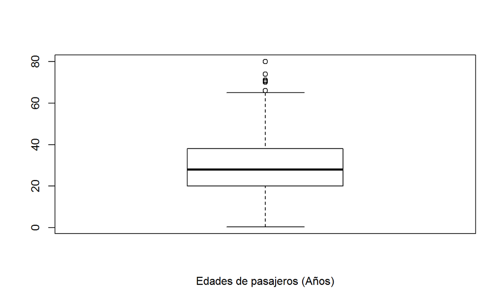

## Histogramas.

Histograma de la edad.

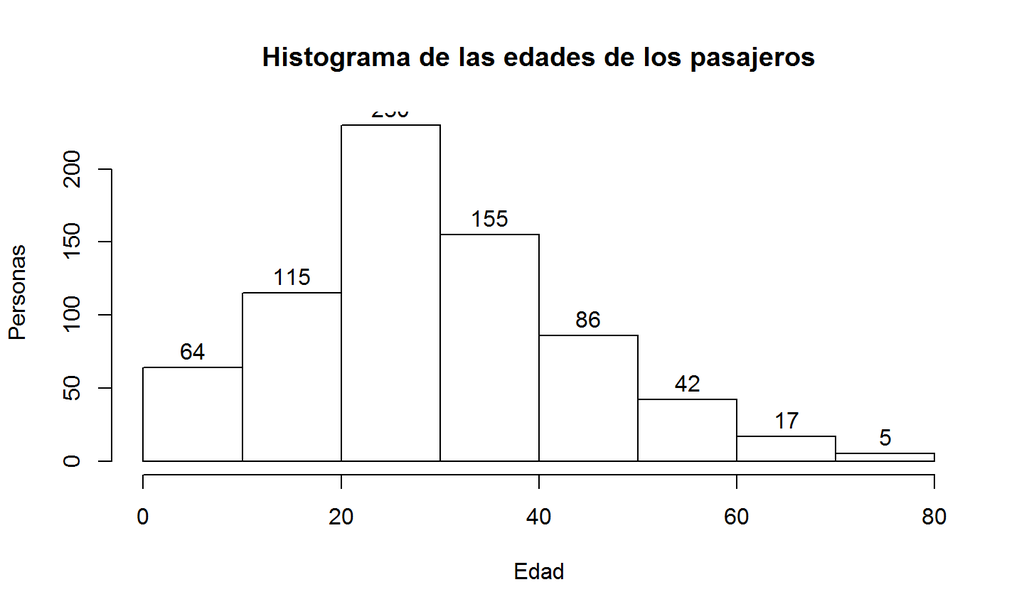

## Cuartiles.

Cuartiles y rango intercuartil de la edad.

```
##    Min. 1st Qu.  Median    Mean 3rd Qu.    Max.
##    0.42   20.12   28.00   29.70   38.00   80.00
```

```
## [1] 17.875
```

```
## $M
## [1] 24
```

## Cuartiles. [2]

Cuartiles y rango intercuartil de la tarifa.

```
##    Min. 1st Qu.  Median    Mean 3rd Qu.    Max.
##    0.00    7.91   14.45   32.20   31.00  512.30
```

```
## [1] 23.0896
```

```
## $M
## [1] 8.05
```

## Correlación

Correlación: Correspondencia o relación recíproca entre dos o más acciones o fenómenos.

Fórmula: \(r=\frac{n(\Sigma xy) - (\Sigma x)(\Sigma y)}{\sqrt{[n\Sigma x^{2} - (\Sigma x^{2})][[n\Sigma y^{2} - (\Sigma y^{2}]}}\)

```
## [1] 0.09606669
```

## Gráficos de dispersión.

La Gráfica de dispersión de la edad con respecto a la Tarifa.

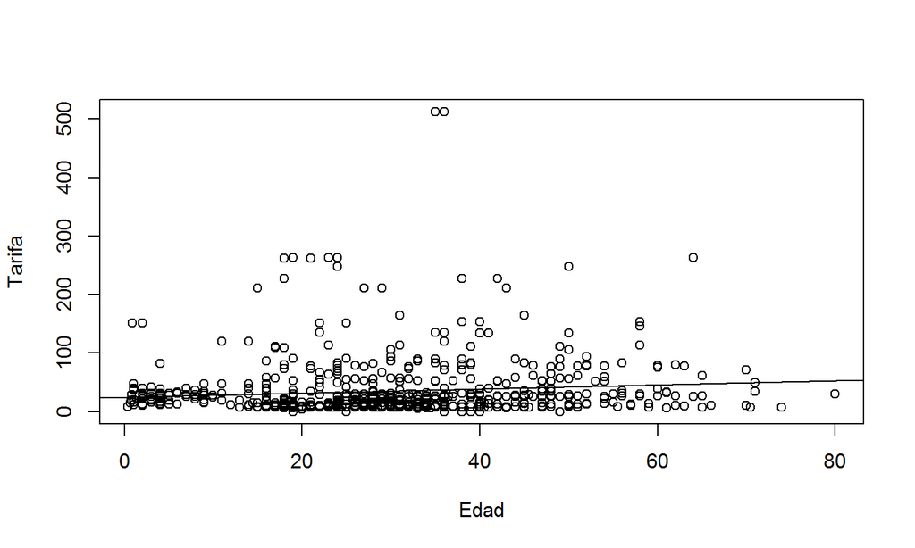

## Clase con respecto a los sobrevivientes.

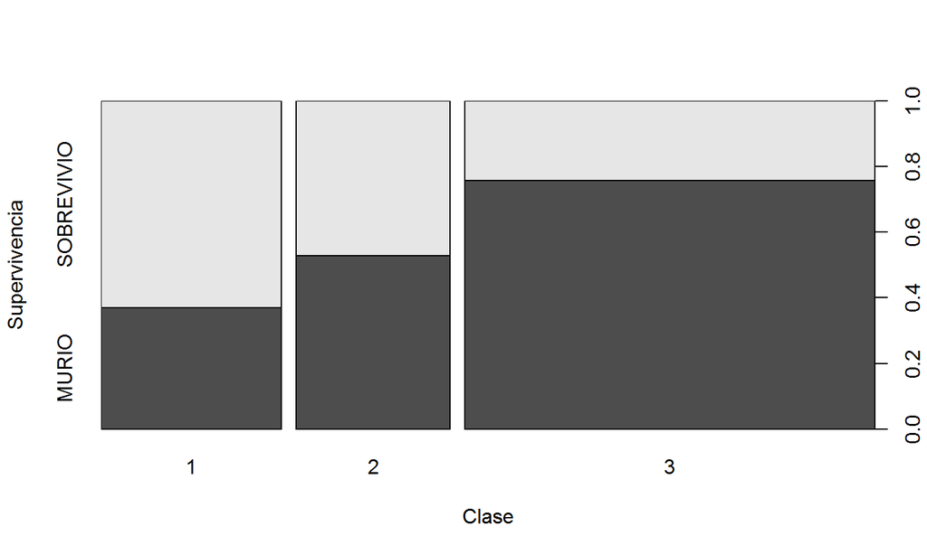

## Sexo con respecto a los sobrevivientes.

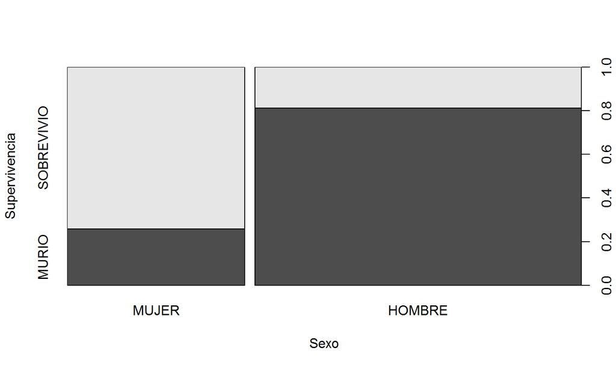

## Sobrevivientes con respecto a la embarcación que subieron abordo del barco.

C = Cherbourg, Q = Queenstown, S = Southampton

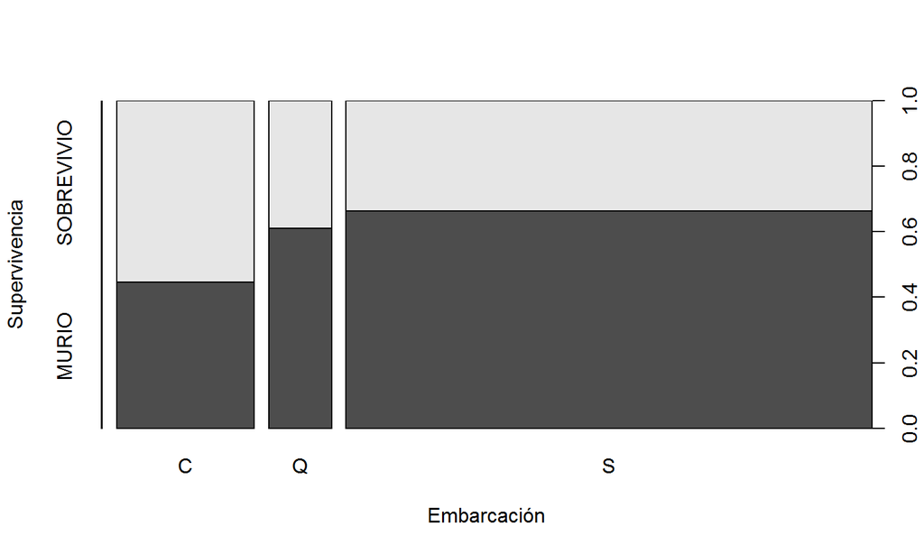